# EDAV Fall 2020 PSet 4

This assignment is designed to help you get started on the final project. Be sure to review the final project instructions (https://edav.info/project.html).

### 1. The Team

[8 points]

1. Who’s on the team? (Include names and UNIs)
2. How do you plan to divide up the work? (Grading is on a group basis. The point of asking is to encourage you to think about this and design a plan.)
3. What is your plan for managing the git/GitHub workflow? That is, who will merge pull requests? How will you attempt to avoid conflicts? How will you communicate?

### 2. The Questions

[10 points]

List three questions that you hope you will be able to answer from your research. (It’s ok if these change as your work progresses.)

### 3. GitHub repo

[8 points]

1. Set up your final project repository following the EDAVproject template. Provide the link to the repo.
2. Make sure that all team members have write access to the repository and have practiced making contributions. Provide a link to the contributors page of your repository showing that all team members have made contributions to the repo (Note that we do not have the ability to see who has write access, only contributors):

### 4. Data Sources

[8 points]

Write a draft of the [Data Sources chapter](https://edav.info/project#report-format).

### 5. Data Transformation

[8 points]

Write a draft of the [Data Transformation chapter](https://edav.info/project#report-format)

### 6. Missing Values

`install.packages("questionr")`

[8 points]

```r
library(readr)
library(questionr)
library(ggplot2)
library(tidyr)
library(scales)
library(tibble)
library(forcats)
library(dplyr)
```

Write a draft of the [Missing Values chapter](https://edav.info/project#report-format)

```r
poms_dat <- readRDS("poms_dat.RDS")
vignette_dat <- readRDS("vignette_dat.RDS")
Baseline <- read_csv("Baseline.csv")
```

Our data missing analysis involves 3 data sets: Mood data, Vignette data and Baseline data.

```r
freq.na(poms_dat)
```

[output not shown]

```r
freq.na(vignette_dat)
```

```
##          missing %
## ID             0 0
## Session        0 0
## vignette       0 0
## score          0 0
```

Among those 3 data sets, only Baseline data has different percentage of values missing. For column patterns, we can see that the top 3 variables have the most missing data: ‘non_heteronormative_3_TEXT’, ‘gender_idetity_5_TEXT’ and ‘race_12_TEXT’ This is quite reasonable since these variables are used to store the explanation part if people choose the ‘other’ option for variable ‘non_heteronormative’, ‘gender_idetity’ and ‘race’, respectively. Therefore, the reason why these 3 columns has leading missing values is people choose common options but rarely the ‘other’ option for ‘non_heteronormative’, ‘gender_idetity’ and ‘race’ variables.

```r
head(freq.na(Baseline),20)
```

```
##                            missing   %
## non_heteronormative_3_TEXT     201 100
## gender_idetity_5_TEXT          199  99
## race_12_TEXT                   197  98
## mother_education                62  31
## father_education                62  31
## period                          58  29
## gender_idetity                  47  23
## contraceptive                   26  13
## loc2                            20  10
## household_income                20  10
## loc1                            19   9
## loc3                            19   9
## coherence6                      19   9
## sibling_age                     19   9
## focus1                          18   9
## focus2                          18   9
## focus3                          18   9
## focus4                          18   9
## focus5                          18   9
## focus6                          18   9
```

For row patterns, with each row represents a student survey results, we found that there were 17 out of 201 students that only fill out a few of survey question and then quit. In fact, we decide to remove those who did not fill out at least 75% of the survey for data cleaning.

```r
rowSums(is.na(Baseline))
```

```
##   [1]   4   4   4   6   5   4   5   4   4   4   4   4   4   4   4   5   5   4
##  [19]   4   4   4   4   4   3 179   6 180   4   4   4   5 178   5   5   7   5
##  [37]   5   4   7   5   5   5   5   5   5   5   6 178   6   6   5   5   5   5
##  [55]   6   5   4   6   5   7   6   5   5   5   5   6   5   5   8   5   7   5
##  [73] 179   3   3   6  75   3   3   3   6   3   3   3   3   3 180   3 179   3
##  [91]   3   3   3   3   3   4   3   3 178 178   3   4   3   4 165   3   3   3
## [109]   3   3   3   3   3   3   3 179   3   3 180   2   3   3   4   3   3   3
## [127]   3   4   3   3   6 178   8   3   3 154   3   3   5 178   3   4   3   3
## [145]   3   3   4   3   4   4   3   5   3   3   3   3   3   2   3   3   3   5
## [163]   5   3   3   4   3   3   3   3 179   3   3   3   1   4   3   4   6   3
## [181]   3   5   3   3   3   3   3   4 180   4   3   4   4   3   4   3   4   3
## [199]   4   4   4
```

Here is a heatmap for row/column missing pattern, where x-axis for columns (survey questions), y-axis for row index (id for students) 1.While yellow cells indicates missing data, we can see patterns of 3 vertical yellow lines (top 3 variables with missing values) and 17 horizontal yellow lines (17 students miss more than 75% questions) 2.There is another pattern that students with id 31-73 have missing values for variable father_education and mother_education.

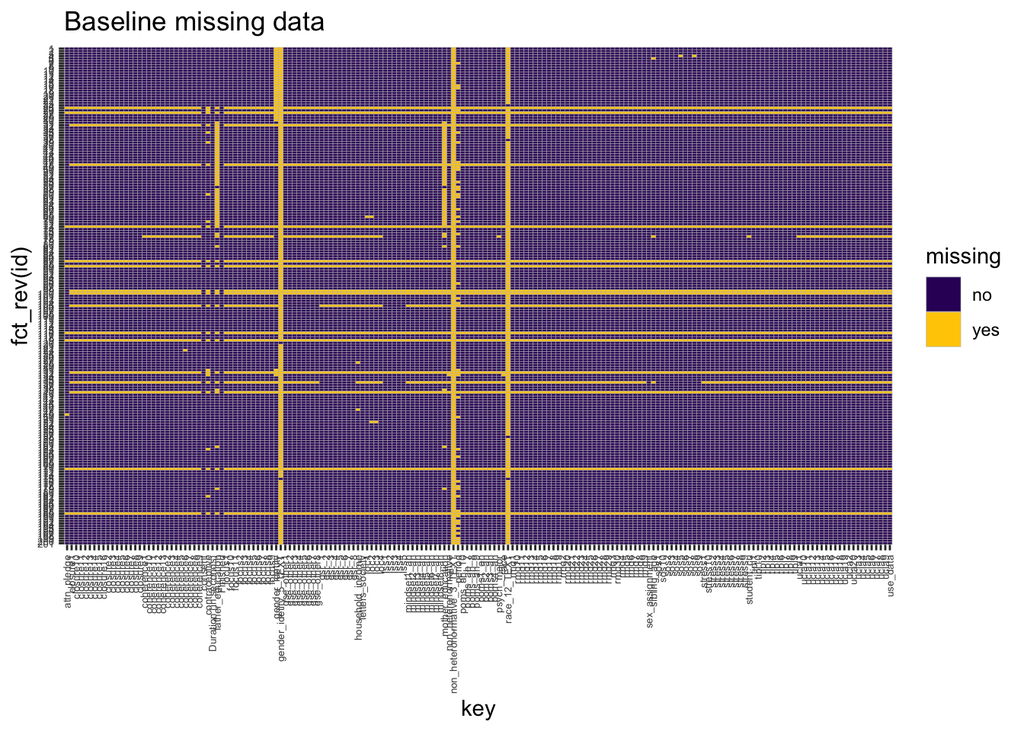

```r
myBaseline <- Baseline %>% rownames_to_column("id") %>% gather(key,value,-id,-sid) %>% mutate(key = factor(key)) %>% group_by(key) %>% ungroup()
myBaseline$missing <- ifelse(is.na(myBaseline$value),"yes","no")
colors <- c("#330066","#FFCC00")
myBaseline$id <- factor(myBaseline$id, levels = unique(myBaseline$id))
ggplot(myBaseline, aes(x = key, y = fct_rev(id))) + geom_tile(aes(fill = missing),color="gray")+scale_fill_manual(values=colors)+ ggtitle("Baseline missing data")+ theme(axis.text.x = element_text(angle = 90,vjust=0.5, hjust=1,size=5),axis.text.y = element_text(size=5))
```